# Lab 06, Experiment 2

# PAM Transmitter/Receiver

```python
%matplotlib inline
```

```python
# Importing all required modules

from pylab import *
import pam12 as pam
import showfun as sf
import wavfun as wf
import filtfun as ff
import ascfun as af
```

# Part (a)

**Update your pam11 function to include the RRCf (root raised cosine in frequency) pulse and rename it pam12.py**

**The code for rrcf is appended into pam11 and renamed it to pam12. The code is attached in the folder. If required, please load the code here to see using "%load pam12.py". The module pam12 is already imported here with the name of pam.**

```python
FB = 100                                                     # Baud Rate
Fs = 44100                                                   # Sampling Frequency
txt='Test'                                                   # Text to be converted to binary
an = af.asc2bin(txt)                                         # Binary Sequence for txt
dn_hat = 2*an-1                                              # Polar binary sequence for txt
dn = hstack((array([0,0]),dn_hat,array([0,0])))              # Appending two zeros in starting and end of the sequence
```

```python
pparms = [4,0.4]
tt,yt=pam.pam12(dn,FB,Fs,'rrcf',pparms)                          # Converting the sequence to PAM signal
```

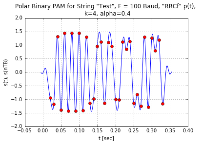

```python
# Plotting the PAM signal of 'Test' using rrcf pulse

plot(tt,yt)
plot(arange(2,len(dn_hat)+2)/FB, yt[int(2.5*Fs/FB):len(tt)-int(2*Fs/FB):int(Fs/FB)], 'or')
title('Polar Binary PAM for String "%s", F = %s Baud, "RRCf" p(t), \n k=%s, alpha=%s' %(txt,FB,pparms[0],pparms[1]))
ylabel('s(t), s(nTB)')
xlabel('t [sec]')
ylim(-2,2)
grid()
show()
```

# Part (b)

**For the module pamfun.py, write a Python function called pamrcvr10 (PAM receiver V1.0) which implements a receiver, with matched filter and sampler, for (noisy) PAM signals.**

**Below code is generated for function pamrcvr10 and is appended in the module pam12.py for further use.**

```python
# %%writefile -a  pam12.py

def pamrcvr10(tt, rt, FBparms, ptype, pparms=[]):
    """
    Pulse amplitude modulation receiver with matched filter:
    r(t) -> b(t) -> bn.
    V1.0 for 'man', 'rcf', 'rect', 'rrcf', 'sinc', and 'tri'
    pulse types.
    >>>>> bn, bt, ixn = pamrcvr10(tt, rt, FBparms, ptype, pparms) <<<<<
    where tt: time axis for r(t)
    rt: received (noisy) PAM signal r(t)
    FBparms: = [FB, dly]
    FB: Baud rate of PAM signal, TB=1/FB
    dly: sampling delay for b(t) -> b_n as a fraction of TB
    sampling times are t=n*TB+t0 where t0 = dly*TB
    ptype: pulse type from list ('man','rcf','rect','rrcf','sinc','tri')
    pparms not used for 'man','rect','tri'
    pparms = [k, alpha] for 'rcf','rrcf'
    pparms = [k, beta] for 'sinc'
    k: "tail" truncation parameter for 'rcf','rrcf','sinc'
    (truncates p(t) to -k*TB <= t < k*TB)
    alpha: rolloff parameter for ('rcf','rrcf'), 0<=alpha<=1
    beta: Kaiser window parameter for 'sinc'
    bn: received DT sequence after sampling at t=n*TB+t0
    bt: received PAM signal b(t) at output of matched filter
    ixn: indexes where b(t) is sampled to obtain b_n
    """

    FB = FBparms[0]
    t0 = FBparms[1]
    Fs = (len(tt)-1)/(tt[-1]-tt[0])

    # ***** Set up matched filter response h_R(t) *****
    TB = 1/float(FB)                                            # Time per symbol
    ptype = ptype.lower()                                       # Convert ptype to lowercase

    # Set left/right limits for p(t)

    if (ptype=='rect' or ptype=='man'):                                         # Rectangular or Manchester p(t)
        kL = -0.5; kR = -kL
    else:
        kL = -1.0; kR = -kL                                     # Default left/right limits

    ixpL = ceil(Fs*kL*TB)                                       # Left index for p(t) time axis
    ixpR = ceil(Fs*kR*TB)                                       # Right index for p(t) time axis
    ttp = arange(ixpL,ixpR)/float(Fs)                           # Time axis for p(t)
    pt = zeros(len(ttp))                                        # Initialize pulse p(t)
    if (ptype=='rect'):                                         # Rectangular p(t)
        ix = where(logical_and(ttp>=kL*TB, ttp<kR*TB))[0]
        pt[ix] = ones(len(ix))
    elif (ptype == 'tri'):
        pt = array([(1+i*1/TB) if i*1/TB+1 < 1.0 else (1-i*1/TB) for i in list(ttp)])
    elif (ptype=='sinc'):
        k=pparms[0]
        kL = kL*k; kR = -kL
        ixpL = ceil(Fs*kL*TB)        # Left index for p(t) time axis
        ixpR = ceil(Fs*kR*TB)        # Right index for p(t) time axis
        ttp = arange(ixpL,ixpR)/float(Fs)     # Time axis for p(t)
        pt = zeros(len(ttp))
        beta=pparms[1]
        pt = array([sin(pi*t/TB)/(pi*t/TB) if t!= 0  else  1.0 for t in list(ttp)])
        pt=pt*kaiser(len(pt), beta)
    elif (ptype=='man'):
        pt= ones(len(ttp))
        ixpn= where(logical_and((ttp>=(kL*TB)),(ttp<0.0)))[0]
        pt[ixpn]= (-1.0)*ones(len(ixpn))
        #pt=ones(len(ttp))
        #ix = where(logical_and(ttp>=kL*TB, ttp<0))[0]
        #pt[ix] = -1*ones(len(ix))  #hstack((ones(int(len(ix)/2))-2, ones(len(pt)-int(len(pt)/2))))
    elif (ptype=='rcf'):
        k=pparms[0]
        alpha=pparms[1]
        kL = kL*k; kR = -kL
        ixpL = ceil(Fs*kL*TB)        # Left index for p(t) time axis
        ixpR = ceil(Fs*kR*TB)        # Right index for p(t) time axis
        ttp = arange(ixpL,ixpR)/float(Fs)     # Time axis for p(t)
        pt = zeros(len(ttp))
        ix0= where(ttp==0)[0]
        pt[ix0] = array([1.0])
        ix0 = where(ttp==TB/(2*alpha))[0]
        pt[ix0] = array([0])
        ix0 = where(ttp==-TB/(2*alpha))[0]
        pt[ix0] = array([0])
        ix_rest = where(logical_and(logical_and(ttp!=0, ttp != TB/(2*alpha)), ttp != -TB/(2*alpha) ))[0]
        ttp = ttp[ix_rest]
        pt[ix_rest] = (sin(pi*ttp/TB)/(pi*ttp/TB))*(cos(pi*alpha*ttp/TB)/(1-np.power(2*alpha*ttp/TB,2)))
    elif ptype=='rrcf':
        k=pparms[0]
        alpha=pparms[1]
        kL = kL*k; kR = -kL
        ixpL = ceil(Fs*kL*TB)        # Left index for p(t) time axis
        ixpR = ceil(Fs*kR*TB)        # Right index for p(t) time axis
        ttp = arange(ixpL,ixpR)/float(Fs)     # Time axis for p(t)
        pt = zeros(len(ttp))
        ix0= where(ttp==0)[0]
        pt[ix0] = 1 - alpha +(4*alpha/pi)
        ix0 = where(logical_or(ttp== -TB/(4*alpha), ttp==TB/(4*alpha)))[0]
        pt[ix0] = (alpha/2**0.5)*(((1+2/pi)*sin(pi/(4*alpha))) + ((1-2/pi)*cos(pi/(4*alpha))))
        ix0 = where(logical_and(logical_and(ttp != 0, ttp != TB/(4*alpha)),ttp != -TB/(4*alpha)))[0]
        t=ttp[ix0]
        p = pi*t/TB
        a = alpha*t/TB
        pt[ix0]= TB*(sin((1-alpha)*p) + 4*a*cos((1+alpha)*p))/(pi*t*(1-(4*a)**2))
    else:
        print("ptype '%s' is not recognized" % ptype)
    hRt = pt[::-1]                                              # h_R(t) = p(-t)
    hRt = Fs/sum(np.power(pt,2.0))*hRt                          # h_R(t) normalized

    # ***** Filter r(t) with matched filter h_R(t)
    bt = convolve(rt,hRt)/float(Fs)                             # Matched filter b(t)=r(t)*h_R(t)
    bt = bt[-ixpL:len(tt)-ixpL]                                 # Trim b(t)

    # ***** Sample b(t) at t=n*TB+t0 to obtain b_n *****
    N = ceil(FB*(tt[-1]-tt[0]))                                 # Number of symbols
    ixn = array(around((arange(N)+0.5+t0)*Fs/FB),int)           # Sampling indexes
    ix = where(logical_and(ixn>=0,ixn<len(tt)))[0]
    ixn = ixn[ix]                                               # Trim to existing indexes
    bn = bt[ixn]                                                # DT sequence sampled at t=n*TB+t0

    return bn, bt, ixn
```

# Part (c)

**Reception of noisy PAM signals. The wav-files pamsig601.wav, pamsig602.wav, and pamsig603.wav contain received PAM signals r(t) with additive white Gaussian noise. The data in the PAM signals is ASCII text, 8 bits/character, LSB-first, transmitted as polar binary with logical 0 → −A and logical 1 → +A where A is an amplitude level that was chosen so that the wav-files (with the noise added) have amplitude less than 1. Use showpsd in combination with trapfilt and time domain plots to analyze the PAM signals sufficiently so that you can use your pamrcvr10 function to recover the ASCII text in each case.**

**For pamsig601.wav**

```python
rt,Fs = wf.wavread('pamsig601.wav')                           # Extracting signal information from pamsig601.wav
```

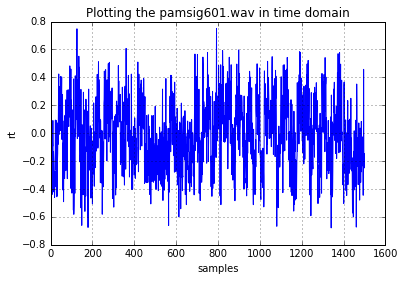

```python
# Plotting the signal in time domain

plot(rt[0:1500])
xlabel('samples')
ylabel('rt')
title('Plotting the pamsig601.wav in time domain')
grid()
show()
```

```python
yt,n = ff.trapfilt(rt,Fs, fL = 1000, k=10, alfa=0.2)          # Filtering the extracted signal from pamsig601.wav
```

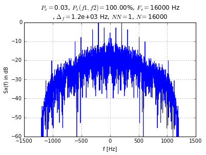

```python
sf.showpsd(yt,Fs,[-1200,1200,-60],Fs)                         # Plotting the PSD of the filtered signal
```

**We are unable to find rate from the above plots. So we will square it and try to get the bitrate from PSD.**

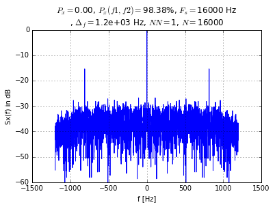

```python
sf.showpsd(yt**2,Fs,[-1200,1200,-60],Fs)                      # Plotting the PSD of the squared filtered signal
```

**From the above PSD of squared output of the signal pamsig601.wav, we observe the bit rate to be 815 Hz.**

**Now, we will try to decode the message in the PAM signal of pamsig601.wav.**

```python
# Defining the required parameters

FB = 815                                              # Bit rate is 815 Hz.
nb = int(len(yt)/Fs*FB) - int(len(yt)/Fs*FB)%8        # Number of bits received
nsb = round(Fs/FB)                                    # Number of sample in 1 bit
tlen = nb/FB                                          # Time of the signal
tt = arange(0,tlen,1/Fs)                              # Time axis
FBparms = [FB,0]                                      # FBparms input for pamrcvr10
ptype = 'rrcf'                                        # Pulse type
pparms = [10,0.2]                                     # pparms value for pamrcvr10
```

```python
bn,bt,ixn = pam.pamrcvr10(tt, yt[0:len(tt)], FBparms, ptype, pparms)         # Getting the samples of the signal
```

```python
# Decoding the message signal
ixp = where(bn>0)[0]                                  # indices where bn is positive
bn[ixp] = 1                                           # Making bn = 1 where bn > 0
ixn = where(bn <=0)[0]                                # indices where bn is negative
bn[ixn] = 0                                           # Making bn = 0 where bn > 0
bn = array(bn,int8)                                   # converting list into binary array
print(af.bin2asc(bn))
```

```
The house spider is there to bri~g good luck!
Most spiders have 8 eyes and 8 legs.
Is that why some of them "byte"?
```

**The pulse used in the making PAM signal for pamsig601.wav file is 'rrcf'. The bit rate of the file is found to be 815 hz and the hidden message is successfully decoded as above.**

**For pamsig602.wav**

```python
rt,Fs = wf.wavread('pamsig602.wav')                           # Extracting signal information from pamsig602.wav
```

```python
yt,n = ff.trapfilt(rt,Fs, fL = 1000, k=10, alfa=0.2)          # Filtering the extracted signal from pamsig601.wav
```

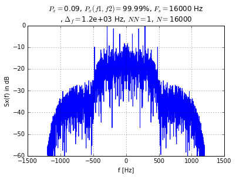

```python
sf.showpsd(yt,Fs,[-1200,1200,-60],Fs)                         # Plotting the PSD of the filtered signal
```

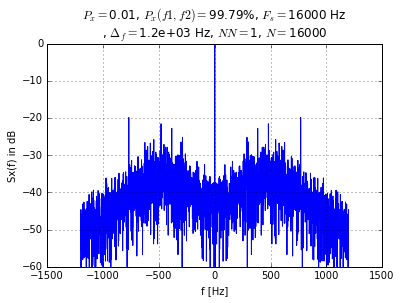

```python
sf.showpsd(yt**2,Fs,[-1200,1200,-60],Fs)                      # Plotting the PSD of the squared filtered signal
```

**From the above PSD of squared output of the signal pamsig602.wav, we observe the bit rate to be 770 Hz.**

**Now, we will try to decode the message in the PAM signal of pamsig602.wav.**

```python
# Defining the required parameters

FB = 770                                              # Bit rate is 815 Hz.
nb = int(len(yt)/Fs*FB) - int(len(yt)/Fs*FB)%8        # Number of bits received
nsb = round(Fs/FB)                                    # Number of sample in 1 bit
tlen = nb/FB                                          # Time of the signal
tt = arange(0,tlen,1/Fs)                              # Time axis
FBparms = [FB,0]                                      # FBparms input for pamrcvr10
ptype = 'rrcf'                                        # Pulse type
pparms = [10,0.2]                                     # pparms value for pamrcvr10
```

```python
bn,bt,ixn = pam.pamrcvr10(tt, yt[0:len(tt)], FBparms, ptype, pparms)         # Getting the samples of the signal
```

```python
# Decoding the message signal
ixp = where(bn>0)[0]                                  # indices where bn is positive
bn[ixp] = 1                                           # Making bn = 1 where bn > 0
ixn = where(bn <=0)[0]                                # indices where bn is negative
bn[ixn] = 0                                           # Making bn = 0 where bn > 0
bn = array(bn,int8)                                   # converting list into binary array
print(af.bin2asc(bn))
```

```
I was thrown out of college for cheating on the metaphysics exam;
I looked into the soul of the boy sitting next to me. (Woody Allen)
```

**The pulse used in the making PAM signal for pamsig602.wav file is 'rrcf'. The bit rate of the file is found to be 770 hz and the hidden message is successfully decoded as above.**

**For pamsig603.wav**

```python
rt,Fs = wf.wavread('pamsig603.wav')                           # Extracting signal information from pamsig603.wav
```

```python
yt,n = ff.trapfilt(rt,Fs, fL = 1000, k=10, alfa=0.2)          # Filtering the extracted signal from pamsig601.wav
```

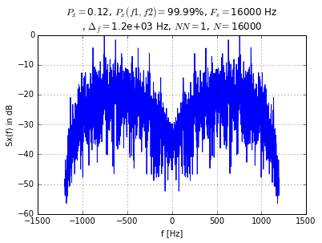

```python
sf.showpsd(yt,Fs,[-1200,1200,-60],Fs)                         # Plotting the PSD of the filtered signal
```

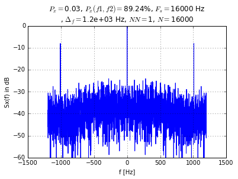

```python
sf.showpsd(yt**2,Fs,[-1200,1200,-60],Fs)                      # Plotting the PSD of the squared filtered signal
```

**From the above PSD of squared output of the signal pamsig603.wav, we observe the bit rate to be 1010 Hz.**

**Now, we will try to decode the message in the PAM signal of pamsig603.wav.**

```python
# Defining the required parameters

FB = 1010                                             # Bit rate is 815 Hz.
nb = int(len(yt)/Fs*FB) - int(len(yt)/Fs*FB)%8        # Number of bits received
nsb = round(Fs/FB)                                    # Number of sample in 1 bit
tlen = nb/FB                                          # Time of the signal
tt = arange(0,tlen,1/Fs)                              # Time axis
FBparms = [FB,0]                                      # FBparms input for pamrcvr10
ptype = 'man'                                         # Pulse type
```

```python
bn,bt,ixn = pam.pamrcvr10(tt, yt[0:len(tt)], FBparms, ptype, pparms)         # Getting the samples of the signal
```

```python
# Decoding the message signal
ixp = where(bn>0)[0]                                  # indices where bn is positive
bn[ixp] = 1                                           # Making bn = 1 where bn > 0
ixn = where(bn <=0)[0]                                # indices where bn is negative
bn[ixn] = 0                                           # Making bn = 0 where bn > 0
bn = array(bn,int8)                                   # converting list into binary array
print(af.bin2asc(bn))
```

```
The quick brown fox jumps over the lazy dog 0123456789.
The quick brown fox jumps over the lazy dog 0123456789.
The quick brown fox jumps over the lazy dog 0123456789.
```

**The pulse used in the making PAM signal for pamsig603.wav file is 'man'. The bit rate of the file is found to be 1010 hz and the hidden message is successfully decoded as above.**